# Danish Kings

William Mailil

26-05-2026

Here I will be loading the kings.csv into R using the `tidyverse` package to calculate and explore the kings’ duration of reign with pipes `%>%` in `dplyr` and plot it over time.

## Loading the kings.csv

Bellow I my create a `kings` object using the `tidyverse` read_csv function because the kings.csv has it’s columns separated by commas. I have tried other functions, read.csv and read_csv give the object 11 columns, read.csv2 and read_csv2 only give the object 1 column. This is because read.csv2 and read_csv2 work for semicolon separated values. After the object has been created I use class() to inspect it. The object now contains “spec_tbl_df” “tbl_df” “tbl” “data.frame”.

```r
library(tidyverse)
library(here)
kings <-read_csv("data/kings.csv", na=c("NULL",""))
class(kings)
```

```
## [1] "spec_tbl_df" "tbl_df"      "tbl"         "data.frame"
```

```r
head(kings)
```

```
## # A tibble: 6 × 11
##   Name     House Start_year End_year Birth_year Death_year Gender Dynasty Source
##   <chr>    <chr>      <dbl>    <dbl>      <dbl>      <dbl> <chr>  <chr>   <chr>
## 1 Gorm de… Gorm         936      958        908        958 M      Jellin… https…
## 2 Harald … Gorm          NA       NA        936        985 M      Jellin… https…
## 3 Toke_Go… Gorm         985      986         NA        986 M      Jellin… https…
## 4 Svend 1… Gorm          NA       NA         NA       1014 M      Jellin… https…
## 5 Harald … Gorm        1014     1018        963         NA M      Jellin… https…
## 6 Knud 1.… Gorm        1018     1035         NA       1035 M      Jellin… https…
## # ℹ 2 more variables: BirthDMY <chr>, DeathDMY <chr>
```

```r
glimpse(kings)
```

```
## Rows: 57
## Columns: 11
## $ Name       <chr> "Gorm den Gamle", "Harald 1. Blåtand", "Toke_Gormsen", "Sve…
## $ House      <chr> "Gorm", "Gorm", "Gorm", "Gorm", "Gorm", "Gorm", "Gorm", "Fa…
## $ Start_year <dbl> 936, NA, 985, NA, 1014, 1018, 1035, 1042, 1047, 1074, 1080,…
## $ End_year   <dbl> 958, NA, 986, NA, 1018, 1035, 1042, 1047, 1074, 1080, 1086,…
## $ Birth_year <dbl> 908, 936, NA, NA, 963, NA, 995, 1018, 1024, 1019, 1041, 104…
## $ Death_year <dbl> 958, 985, 986, 1014, NA, 1035, 1042, 1047, 1076, 1080, 1086…
## $ Gender     <chr> "M", "M", "M", "M", "M", "M", "M", "M", "M", "M", "M", "M",…
## $ Dynasty    <chr> "Jellingdynastiet", "Jellingdynastiet", "Jellingdynastiet",…
## $ Source     <chr> "https://da.wikipedia.org/wiki/Gorm_den_Gamle", "https://da…
## $ BirthDMY   <chr> "908", "936", NA, "17/04/963", "994", "995", "1018", "1024"…
## $ DeathDMY   <chr> "958", "987", NA, "03/02/1014", "1018", "12/11/1035", "08/0…
```

## Calculating the duration of reign for all rulers

I use the `mutate` function by subtracting the `Start_year` from the `End_year` columns and tell R to ignore the rows in these which are blank. The result is made into a new column called `duration`in a new object.

```r
# YOUR CODE
kings %>%
  filter(!is.na(Start_year)&!is.na(End_year)) %>%
  mutate(duration=End_year-Start_year) -> kings_duration

kings_duration %>%
  select(duration)
```

```
## # A tibble: 52 × 1
##    duration
##       <dbl>
##  1       22
##  2        1
##  3        4
##  4       17
##  5        7
##  6        5
##  7       27
##  8        6
##  9        6
## 10        9
## # ℹ 42 more rows
```

## Calculating the average duration of reign for all rulers

Same as above except in the final step i use the `summarize` function to calculate the mean duration.

```r
# YOUR CODE
kings_duration %>%
  select(duration) %>%
  summarize(mean_duration = mean(duration))
```

```
## # A tibble: 1 × 1
##   mean_duration
##           <dbl>
## 1          19.6
```

## How many and which kings enjoyed a longer-than-average duration of reign?

I use the `filter()` function on the `duration` column on `kings_duration` object. I display the result and count the rows with `count()`

```r
# YOUR CODE
kings_duration %>%
  filter(duration>19.57692)
```

```
## # A tibble: 25 × 12
##    Name    House Start_year End_year Birth_year Death_year Gender Dynasty Source
##    <chr>   <chr>      <dbl>    <dbl>      <dbl>      <dbl> <chr>  <chr>   <chr>
##  1 Gorm d… Gorm         936      958        908        958 M      Jellin… https…
##  2 Svend … Estr…       1047     1074       1024       1076 M      <NA>    https…
##  3 Niels   Estr…       1104     1134       1055       1134 M      Jellin… https…
##  4 Valdem… Estr…       1157     1182       1131       1182 M      Jellin… https…
##  5 Knud 4. Estr…       1182     1202       1163       1202 M      Jellin… https…
##  6 Valdem… Estr…       1202     1241       1170       1241 M      Jellin… https…
##  7 Erik 5… Estr…       1259     1286       1249       1286 M      Jellin… https…
##  8 Erik 6… Estr…       1286     1319       1274       1319 M      Jellin… https…
##  9 Valdem… Estr…       1340     1375       1320       1375 M      Jellin… https…
## 10 Erik 7… Pome…       1396     1439       1382       1459 M      Jellin… https…
## # ℹ 15 more rows
## # ℹ 3 more variables: BirthDMY <chr>, DeathDMY <chr>, duration <dbl>
```

```r
kings_duration %>%
  filter(duration>19.57692) %>%
  count()
```

```
## # A tibble: 1 × 1
##       n
##   <int>
## 1    25
```

## How many days did the three longest-ruling monarchs rule?

First I sort the rulers by `duration` in the descending order. Then I select the three longest-ruling monarchs with the `slice_max()` function. Lastly I use `mutate()` to create the `Days` column where you calculate the total number of days they ruled * BONUS: consider the transition year (with 366 days) in your calculation!

```r
# YOUR CODE
kings_duration %>%
  filter(duration>19.57692) %>%
  select(Name,duration) %>%
  arrange(desc(duration))
```

```
## # A tibble: 25 × 2
##    Name                 duration
##    <chr>                   <dbl>
##  1 Christian 4.               60
##  2 Margrete 2.                51
##  3 Erik 7. af Pommern         43
##  4 Christian 9.               43
##  5 Christian 7.               42
##  6 Valdemar 2. Sejr           39
##  7 Valdemar 4. Atterdag       35
##  8 Christian 10.              35
##  9 Erik 6. Menved             33
## 10 Chrstian 1.                33
## # ℹ 15 more rows
```

```r
kings_duration %>%
  filter(duration>19.57692) %>%
  select(Name, duration) %>%
  slice_max(duration,n=3)
```

```
## # A tibble: 4 × 2
##   Name               duration
##   <chr>                 <dbl>
## 1 Christian 4.             60
## 2 Margrete 2.              51
## 3 Erik 7. af Pommern       43
## 4 Christian 9.             43
```

```r
kings_duration %>%
  mutate(days = duration*365) -> kings_duration_days

# Four rulers show up because I am working with years so two rulers share the number three spot.

kings_duration_days %>%
  select(Name, days) %>%
  slice_max(days,n=3)
```

```
## # A tibble: 4 × 2
##   Name                days
##   <chr>              <dbl>
## 1 Christian 4.       21900
## 2 Margrete 2.        18615
## 3 Erik 7. af Pommern 15695
## 4 Christian 9.       15695
```

## Plotting the kings’ duration of reign through time

Before I plot the duration of reign column in `ggplot` with `geom_point()` and `geom_smooth()` I should make a new column `midyear` by adding `Sart_year` to `duration` divided by two. I can now plot `Mid_year` along the x-axis and `duration` along y-axis * BONUS: add a title, nice axis labels to the plot and make the theme B&W and font bigger to make it nice and legible!

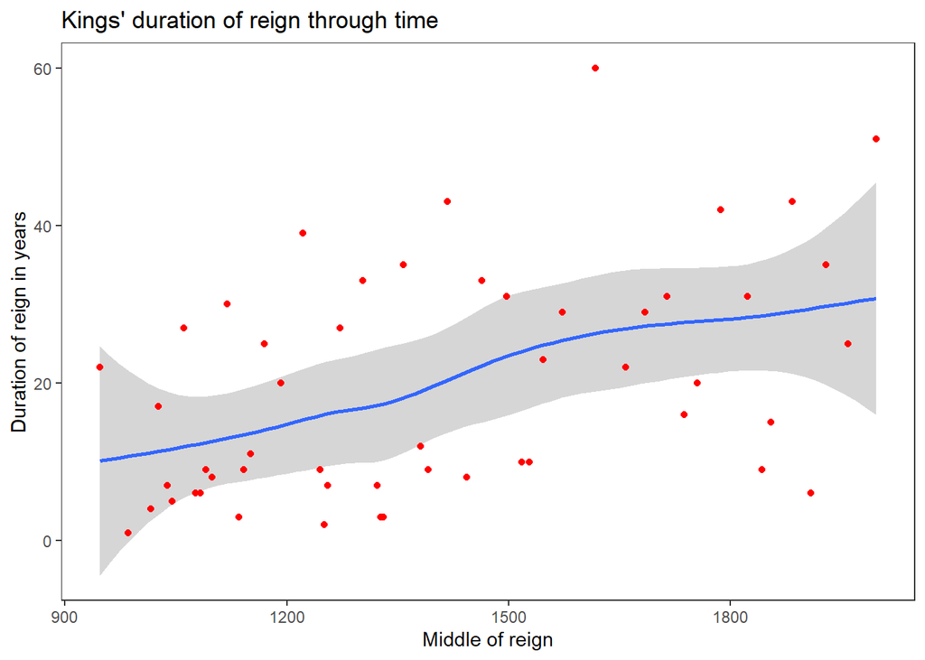

```r
# YOUR CODE
kings_duration_days %>%
  mutate(Mid_year=Start_year+duration/2) -> kings_duration_days_midyear

kings_duration_days_midyear %>%
  ggplot(aes(x = Mid_year, y = duration))+geom_point()+geom_smooth()+
  geom_point(color="red")+
  theme_bw() +
  theme(panel.grid = element_blank())+
  labs(title = "Kings' duration of reign through time",
       x = "Middle of reign",
       y = "Duration of reign in years")
```